# **Time series forecast using Machine Learning Algorithms**

**The 6 machine learning methods used were:**

K-Nearest Neighbor regression (KNN)

Neural Network Auto-Regressive (NNAR)

Generalized Regression Neural Network (GRNN)

Multi-Layer Perceptron (MLP) neural networks

Extreme learning machines (ELM) neural networks

Long short-term memory (LSTM) neural network.

**Topic:** Machine Learning Algorithms for Forecasting and Backcasting Blood Demand Data with Missing Values and Outliers: A Study of Tema General Hospital of Ghana.

```r
#Loading packages
library(tseries)
library("tsfknn")#knn
library("imputeTS") #time series imputation
library("tsfgrnn")# grnn
library(forecast)
library(grid) # visualizations
library(ggplot2)
library(gridExtra)
library("nnfor")# time series with neural networks
library(timetk)
library(tidyverse)
library(lubridate)
library("tsoutliers")
library("nonlinearTseries") #To time for time reversility of a series
library("seastests") #seasonaity test
library(zoo)
#It implements a multilayer RNN, GRU, and LSTM directly in R
library("rnn")
library("keras")
library(tensorflow)
##perform Dunn's Test with Bonferroni correction for p-values
library(FSA)
library(nortsTest)
library("car")
```

```r
options(repr.plot.width=8, repr.plot.height=8,repr.plot.res = 300) #Setting plot size
```

```r
#setting a working directory
setwd("C:/Users/user/Desktop/PhD Documents Cardiff_main/PhD Project Chapter 1-6/LATEX PhD Thesis 1/LaTex Files _PhD/Juliet Publication work_Main/Current-Resubmission_IJF_2021/R Scripts")
```

# Importing the data from Tema Blood Bank

```r
# Importing the data from Tema Blood Bank
Blood_data<-read.csv(file="Blood_data_Tema.csv")
head(Blood_data)
```

A data.frame: 6 × 4

|  | YEAR <int> | MONTH <fct> | QTY_DEMANDED <int> | QTY_SUPPLIED <int> |
| --- | --- | --- | --- | --- |
| 1 | 2013 | January | 162 | 136 |
| 2 | 2013 | February | 188 | 202 |
| 3 | 2013 | March | 229 | 225 |
| 4 | 2013 | April | 220 | 204 |
| 5 | 2013 | May | 252 | 251 |
| 6 | 2013 | June | 322 | 353 |

# Declaring time series data

```r
# Declaring time series data
Demand_timeseries<- ts(Blood_data$QTY_DEMANDED, start=c(2013,1), end=c(2020, 9), frequency=12)

Demand_timeseries

paste("Percentage of missing data in the demand series=",
      round((length(which(is.na(Demand_timeseries)==TRUE))/length(Demand_timeseries))*100,2),"%")
```

A Time Series: 8 × 12

|  | Jan | Feb | Mar | Apr | May | Jun | Jul | Aug | Sep | Oct | Nov | Dec |
| --- | --- | --- | --- | --- | --- | --- | --- | --- | --- | --- | --- | --- |
| 2013 | 162 | 188 | 229 | 220 | 252 | 322 | NA | 340 | 247 | 325 | 342 | 291 |
| 2014 | 247 | 225 | 273 | 264 | 303 | NA | 345 | 338 | 340 | 304 | 244 | 184 |
| 2015 | 181 | 308 | 310 | 316 | NA | 355 | 307 | 251 | 348 | 326 | 369 | NA |
| 2016 | 264 | 270 | 338 | 368 | 360 | 324 | NA | 330 | NA | NA | NA | 203 |
| 2017 | NA | 372 | 1221 | NA | 464 | 110 | NA | 460 | NA | 476 | 390 | 379 |
| 2018 | 450 | 489 | 392 | NA | 309 | 358 | 363 | 438 | 398 | 460 | 343 | 257 |
| 2019 | 291 | 312 | 328 | 327 | 425 | 311 | 308 | 383 | 276 | 227 | 253 | 255 |
| 2020 | 354 | 338 | 384 | 299 | 243 | 332 | 346 | 286 | 233 |  |  |  |

'Percentage of missing data in the demand series= 13.98 %'

```r
statsNA(Demand_timeseries)
```

```
[1] "Length of time series:"
[1] 93
[1] "-------------------------"
[1] "Number of Missing Values:"
[1] 13
[1] "-------------------------"
[1] "Percentage of Missing Values:"
[1] "14%"
[1] "-------------------------"
[1] "Number of Gaps:"
[1] 11
[1] "-------------------------"
[1] "Average Gap Size:"
[1] 1.181818
[1] "-------------------------"
```

[output cut: 18 more lines]

# **First stage: Imputation by Structural Model & Kalman Smoothing**

https://link.springer.com/referenceworkentry/10.1007%2F978-3-642-04898-2_321

https://stats.stackexchange.com/questions/140990/using-kalman-filters-to-impute-missing-values-in-time-series

```r
# Impute the missing values with na_kalman
# (tsAirgap is an example time series provided by the imputeTS package)
#"StructTS" - For using a structural model fitted by maximum likelihood (using StructTS)
#"auto.arima" - For using the state space representation of arima model (using auto.arima)
#nit: Parameter from Kalman Filtering (see KalmanLike). Usually no need to change from default.
#model = "StructTS" or auto.arima
Imputed_demandSeries_byKalman<- na_kalman(Demand_timeseries, model = "StructTS", smooth = TRUE, nit = -1)
Imputed_demandSeries_byKalman
```

A Time Series: 8 × 12

|  | Jan | Feb | Mar | Apr | May | Jun | Jul | Aug | Sep | Oct | Nov | Dec |
| --- | --- | --- | --- | --- | --- | --- | --- | --- | --- | --- | --- | --- |
| 2013 | 162.0000 | 188.0000 | 229.0000 | 220.0000 | 252.0000 | 322.0000 | 239.0045 | 340.0000 | 247.0000 | 325.0000 | 342.0000 | 291.0000 |
| 2014 | 247.0000 | 225.0000 | 273.0000 | 264.0000 | 303.0000 | 282.9887 | 345.0000 | 338.0000 | 340.0000 | 304.0000 | 244.0000 | 184.0000 |
| 2015 | 181.0000 | 308.0000 | 310.0000 | 316.0000 | 319.0142 | 355.0000 | 307.0000 | 251.0000 | 348.0000 | 326.0000 | 369.0000 | 331.0649 |
| 2016 | 264.0000 | 270.0000 | 338.0000 | 368.0000 | 360.0000 | 324.0000 | 379.4099 | 330.0000 | 383.4042 | 396.9003 | 400.5524 | 203.0000 |
| 2017 | 362.8024 | 372.0000 | 1221.0000 | 410.0119 | 464.0000 | 110.0000 | 421.7935 | 460.0000 | 411.1654 | 476.0000 | 390.0000 | 379.0000 |
| 2018 | 450.0000 | 489.0000 | 392.0000 | 381.7138 | 309.0000 | 358.0000 | 363.0000 | 438.0000 | 398.0000 | 460.0000 | 343.0000 | 257.0000 |
| 2019 | 291.0000 | 312.0000 | 328.0000 | 327.0000 | 425.0000 | 311.0000 | 308.0000 | 383.0000 | 276.0000 | 227.0000 | 253.0000 | 255.0000 |
| 2020 | 354.0000 | 338.0000 | 384.0000 | 299.0000 | 243.0000 | 332.0000 | 346.0000 | 286.0000 | 233.0000 |  |  |  |

# Visualize the missing values in this time series

This function visualizes the distribution of missing values within a time series. Therefore, the time series is plotted and whenever a value is NA the background is colored differently. This gives a nice overview, where in the time series most of the missing values occur.

# Visualizing the missing and imputed data (Stage 1)

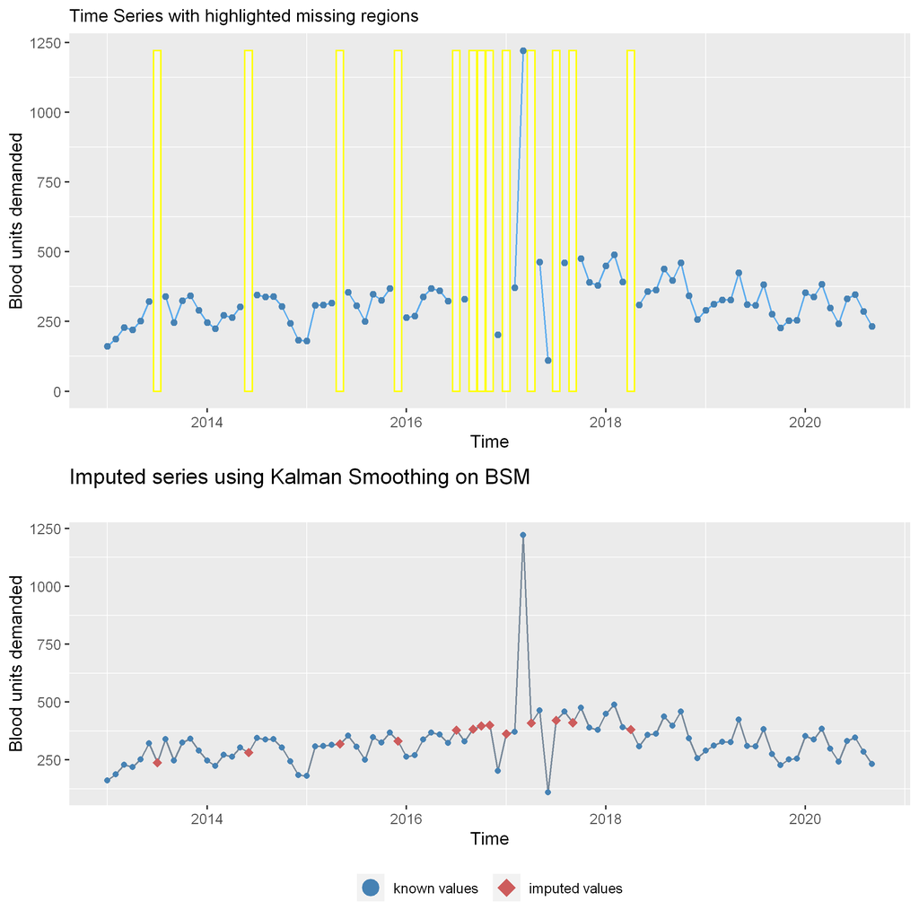

```r
dates<- as.numeric(time(Demand_timeseries))
## 'POSIXct, POSIXt' object
tms <- date_decimal(dates)
p_demand<-ggplot_na_distribution(Demand_timeseries,x_axis_labels=tms,color_missing = "white",color_missing_border ="yellow",
    theme = NULL)+
theme(panel.grid.major = element_blank(),plot.title=element_blank())+
ylab("Blood units demanded")


# Visualizing the imputed data
#Code for visualization

###To change the time axis
#dates<- as.yearmon(time(Demand_timeseries))
dates<- as.numeric(time(Demand_timeseries))
## 'POSIXct, POSIXt' object
tms <- date_decimal(dates)


#Kalman Smoothing via a basic structural model (BSM) for a time series by maximum likelihood
p_demand_imputed<-ggplot_na_imputations(Demand_timeseries,Imputed_demandSeries_byKalman,
    subtitle = "",x_axis_labels=tms,theme = NULL)+
theme(panel.grid.major = element_blank())+
xlab("Time") +ylab("Blood units demanded")+ ggtitle("Imputed series using Kalman Smoothing on BSM")


grid.arrange(p_demand, p_demand_imputed,nrow = 2,ncol = 1)
```

# Stage 2: Determining time series Outliers in demand data; and replacing as missing values

Uses supsmu for non-seasonal series and a periodic stl decomposition with seasonal series to identify outliers and estimate their replacements.

**NB:** We are willing to assume that the outliers are genuinely errors, or that they won’t occur in the forecasting period, then replacing them can make the forecasting task easier.

**Automatic Detection of Outliers in Time Series**

The package (tsoutliers) detects 5 different types of outliers iteratively in time series data:

Additive Outlier (AO): Related to the incident such as recording and typing errors

Innovation Outlier (IO)

Level Shift (LS)

Temporary change (TC)

Seasonal Level Shift (SLS)

https://github.com/cran/tsoutliers/blob/master/R/plot-tsoutliers.R

https://datascienceplus.com/outliers-detection-and-intervention-analysis/

```r
# Importing external scripts
#for plotting series with outliers
source("plot-tsoutliers-script.r")
```

```r
#Method 1 of Stage 2
#Automatic Procedure for Detection of Outliers
#Imputed data via Kalman Smoothing on automatic ARIMA model (1,1,1)
outlier.demand<-tsoutliers::tso(Imputed_demandSeries_byKalman,types = c("AO","LS","TC"),maxit.iloop=10,tsmethod = "auto.arima")
outlier.demand
```

```
Series: Imputed_demandSeries_byKalman
Regression with ARIMA(1,1,1) errors

Coefficients:
         ar1      ma1       AO48      AO51       AO54
      0.3946  -0.8243  -178.7069  828.7315  -322.1497
s.e.  0.1313   0.0727    43.0686   43.1479    43.2961

sigma^2 estimated as 2630:  log likelihood=-490.47
AIC=992.95   AICc=993.94   BIC=1008.08

Outliers:
  type ind    time coefhat  tstat
1   AO  48 2016:12  -178.7 -4.149
2   AO  51 2017:03   828.7 19.207
3   AO  54 2017:06  -322.1 -7.441
```

# **Corrected data based on outlier detection via residuals of fitted ARIMA(1,1,1)**

```r
#Corrected data based on outlier detection via residuals of fitted ARIMA(1,1,1)
demand_corrected_data<- outlier.demand$yadj
demand_corrected_data
```

A Time Series: 8 × 12

|  | Jan | Feb | Mar | Apr | May | Jun | Jul | Aug | Sep | Oct | Nov | Dec |
| --- | --- | --- | --- | --- | --- | --- | --- | --- | --- | --- | --- | --- |
| 2013 | 162.0000 | 188.0000 | 229.0000 | 220.0000 | 252.0000 | 322.0000 | 239.0045 | 340.0000 | 247.0000 | 325.0000 | 342.0000 | 291.0000 |
| 2014 | 247.0000 | 225.0000 | 273.0000 | 264.0000 | 303.0000 | 282.9887 | 345.0000 | 338.0000 | 340.0000 | 304.0000 | 244.0000 | 184.0000 |
| 2015 | 181.0000 | 308.0000 | 310.0000 | 316.0000 | 319.0142 | 355.0000 | 307.0000 | 251.0000 | 348.0000 | 326.0000 | 369.0000 | 331.0649 |
| 2016 | 264.0000 | 270.0000 | 338.0000 | 368.0000 | 360.0000 | 324.0000 | 379.4099 | 330.0000 | 383.4042 | 396.9003 | 400.5524 | 381.7069 |
| 2017 | 362.8024 | 372.0000 | 392.2685 | 410.0119 | 464.0000 | 432.1497 | 421.7935 | 460.0000 | 411.1654 | 476.0000 | 390.0000 | 379.0000 |
| 2018 | 450.0000 | 489.0000 | 392.0000 | 381.7138 | 309.0000 | 358.0000 | 363.0000 | 438.0000 | 398.0000 | 460.0000 | 343.0000 | 257.0000 |
| 2019 | 291.0000 | 312.0000 | 328.0000 | 327.0000 | 425.0000 | 311.0000 | 308.0000 | 383.0000 | 276.0000 | 227.0000 | 253.0000 | 255.0000 |
| 2020 | 354.0000 | 338.0000 | 384.0000 | 299.0000 | 243.0000 | 332.0000 | 346.0000 | 286.0000 | 233.0000 |  |  |  |

# Plot of imputed and corrected data

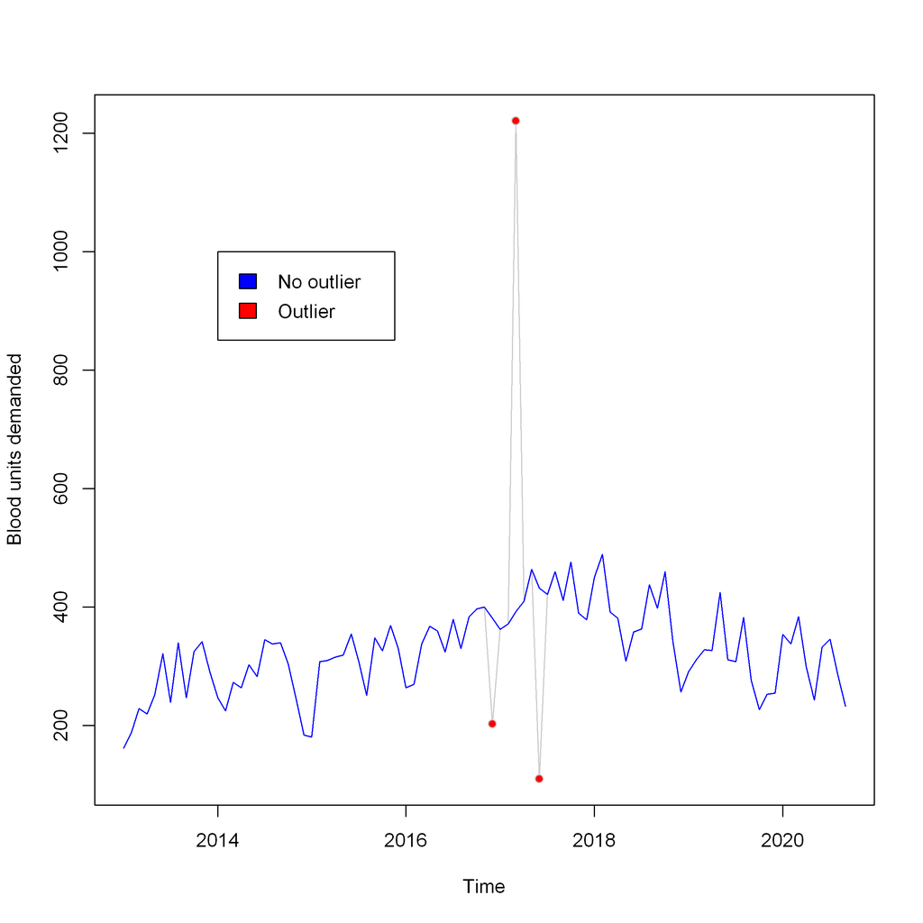

```r
plot.tsoutliers1(outlier.demand,title_name="",
                xlabel="Time", ylabel="Blood units demanded",xaxt=NULL,lwd=3)


text<-c("No outlier", "Outlier")
legend(x=2014,y=1000,legend = text,col=c("blue","red"),
      cex=1, horiz = FALSE,pt.cex = 1,fill=c("blue","red"),ncol=1)
```

# Determining seasonality in the data

Determining the periodicity of the data using Spectral analysis

https://www.ibm.com/support/knowledgecenter/SSLVMB_sub/statistics_casestudies_project_ddita/spss/tutorials/spectral_cat_output.html

Time Series and Spectral Analysis

http://web.stanford.edu/class/earthsys214/notes/series.html

**Seasonality tests**

Different authors have developed a multiplicity of test for seasonality of a given time series. In Ollech and Webel (forthcoming) and Webel and Ollech (forthcoming) we analysed many of these tests and showed a) which tests are the most reliable ones and b) how to combine a small set of tests, to reduce the misclassification rates of the single tests.

Then, we can test, whether these series are seasonal or not, using the WO-test, i.e. the overall seasonality test developed in Webel and Ollech (2019).

**By default, the WO-test combines the results of the QS-test and the kwman-test, both calculated on the residuals of an automatic non-seasonal ARIMA model. If the p-value of the QS-test is below 0.01 or the p-value of the kwman-test is below 0.002, the WO-test will classify the corresponding time series as seasonal.**

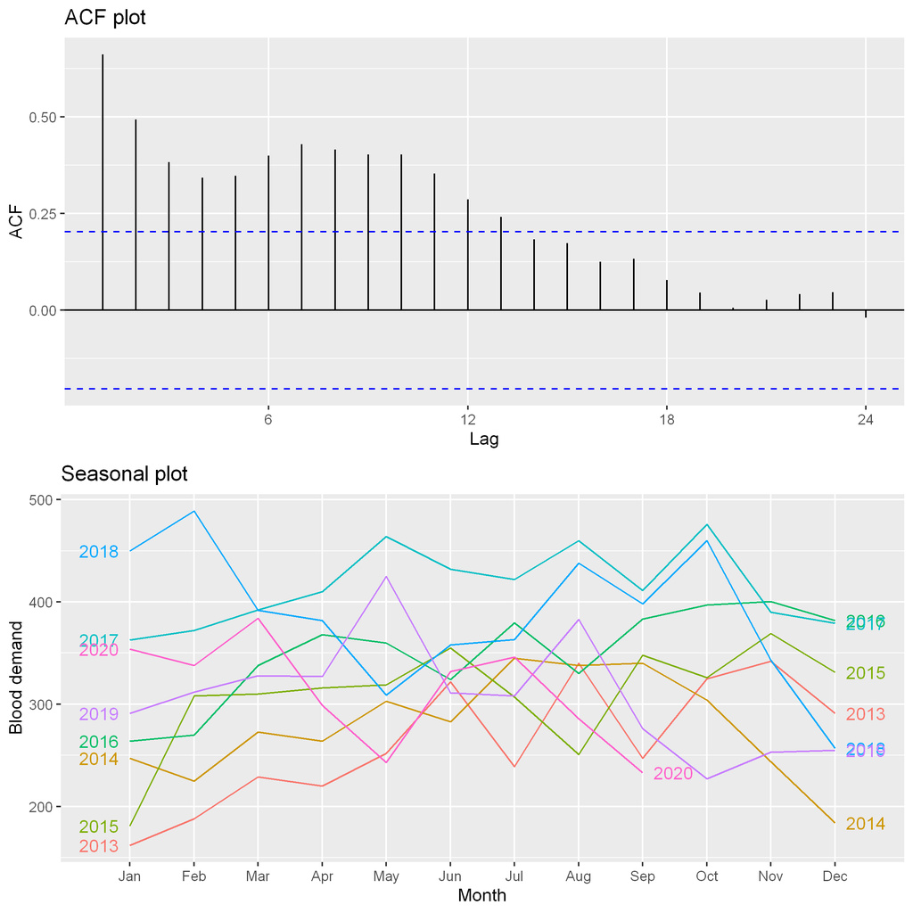

```r
acf_plot<- ggAcf(demand_corrected_data,main="ACF plot")


splot<- ggseasonplot(demand_corrected_data, year.labels=TRUE, year.labels.left=TRUE) +
  ylab("Blood demand") +
  ggtitle("Seasonal plot")

grid.arrange(acf_plot,splot,nrow=2)
```

By default, the WO-test is used to assess the seasonality of a time series and returns a boolean. Alternatively, the QS test (test='qs'), Friedman test (test='fried'), Kruskall-Wallis (test='kw'), F-test on seasonal dummies (test='seasdum') or the Welch test (test='welch') can be used.

Webel, K. and Ollech, D. (2019). An overall seasonality test. Deutsche Bundesbank’s Discussion Paper series.

```r
#The p-values indicate the p-values of the underlying test, i.e. the QS-test, the QS-R test and the KW-R-test.
#Seasonality test for data corrected by KS-BSM correction
summary(wo(demand_corrected_data,freq=12))
```

```
Test used:  WO

Test statistic:  0
P-value:  1 1 0.4593192

The WO - test does not identify  seasonality
```

**ADF test of stationarity**

H0: There series is nonstationarity.

H1: There is stationary

Conclusion: Our demand series is stationary at lag 0.

```r
options(warn=-1)
adf.test(demand_corrected_data,k=0)
#Note: in fact, p.value = 0.01 means p.value <= 0.01
```

```
	Augmented Dickey-Fuller Test

data:  demand_corrected_data
Dickey-Fuller = -4.3048, Lag order = 0, p-value = 0.01
alternative hypothesis: stationary
```

# To time for time reversibility of a series

The time simmetry statistic measures the asymmetry of a time series under time reversal by calculating:

$$E[s_n * s_{n+1}^2] - E[s_n^2 * s_{n+1}]$$

Since (statiionary) linear stochastic series are symmetric under time reversal, this statistic may be used for testing the assertion that the data was generated from a stationary linear stochastic process or not.

Let $Y_t$ be a stationary time series, then the time reversibility statistic is given by

$$T= \frac{1}{n-1} \left[ \sum_{t=1}^{n-1}Y_{t}Y_{t+1}^{2} - \sum_{t=1}^{n-1}Y_{t}^2Y_{t+1} \right]$$

NB: If a strictly stationary time series follows a gaussian linear stochastic process, then the series is time reversal. This can be achieved with a Surrogate data testing (Nonlinear dynamics test).

**REFERENCE:** H. Kantz and T. Schreiber: Nonlinear Time series Analysis (Cambridge university press, second edition, section 7.1.3)

https://books.google.co.uk/books?hl=en&lr=&id=RfQjAG2pKMUC&oi=fnd&pg=PR11&dq=H.+Kantz+and+T.+Schreiber:+Nonlinear+Time+series+Analysis+(Cambridge+university+press,+second+edition,+section+7.1.3)&ots=4TfS2lNB75&sig=IlUELNJYyMSFRGDjY6b44pzuemg#v=onepage&q&f=false

```r
#re-naming the series for the corrected data
demand<-demand_corrected_data
```

# Assessing Normality of Stationary Process

https://cran.r-project.org/web/packages/nortsTest/readme/README.html

**Use the Lobato and Velasco’s normality test of stationary process**

```r
lobato.test(demand)
```

```
	Lobato and Velasco's test

data:  demand
lobato = 0.077884, df = 2, p-value = 0.9618
alternative hypothesis: demand does not follow a Gaussian Process
```

**Surrogate data testing**

```r
#For demand_STLKS series
yt=demand #the series
TimeRevStats<- sum(yt[1:(length(yt)-1)]*yt[2:length(yt)]^2-yt[1:(length(yt)-1)]^2*yt[2:length(yt)])/(length(yt)-1)

TimeRevStats
```

31365.2559304008

```r
# Time Reversibility statistic
timeAsymmetry(demand)
```

31365.2559304008

# Surrogate data testing (Nonlinear dynamics test)

This function tests the null hypothesis (H0) stating that the series is a gaussian linear process. The test is performed by generating several surrogate data according to H0 and comparing the values of a discriminating statistic between both original data and the surrogate data. If the value of the statistic is significantly different for the original series than for the surrogate set, the null hypothesis is rejected and nonlinearity assumed.

Null Hypothesis: Data comes from (gaussian) linear stochastic process

Reject Null hypothesis:

Original data's stat is significant larger than surrogates' stats

To test with a significance level of α if the statistic from the original data is smaller than the expected value under the null hypothesis (a one-side test), K/α − 1 surrogates are generated. The null hypothesis is then rejected if the statistic from the data has one of the K smallest values. For a two-sided test, (2K/α)−1 surrogates are generated. The null hypothesis is rejected if the statistic from the data gives one of the K smallest or largest values.

The surrogate data is generated by using a phase randomization procedure (based on Fast Fourier Transform of the series).

https://arxiv.org/abs/0812.2380

The two most commonly used algorithms for generating surrogates are the amplitude adjusted Fourier transform (AAFT) and the iterated amplitude adjusted Fourier transfom (IAAFT) algorithm. Both the AAFT and IAAFT algorithm conserve the amplitude distribution in real space and reproduce the power spectrum (PS) of the original data set very accurately

Although we have postponed its discussion until the end of this vignette, the first step before studying a system using nonlinear analysis techniques should be checking that the data shows indeed some degree of nonlinearity

https://cran.r-project.org/web/packages/nonlinearTseries/vignettes/nonlinearTseries_quickstart.html

https://cran.r-project.org/web/packages/nonlinearTseries/nonlinearTseries.pdf

```r
st_demand <- surrogateTest(demand,significance = 0.05,one.sided = F,K=5,
                   FUN = timeAsymmetry, do.plot=F)

st_demand$data.statistic

#st$surrogates.statistics
```

```
Computing statistics


Null Hypothesis: Data comes from a linear stochastic process

Accept Null hypothesis
```

31365.2559304008

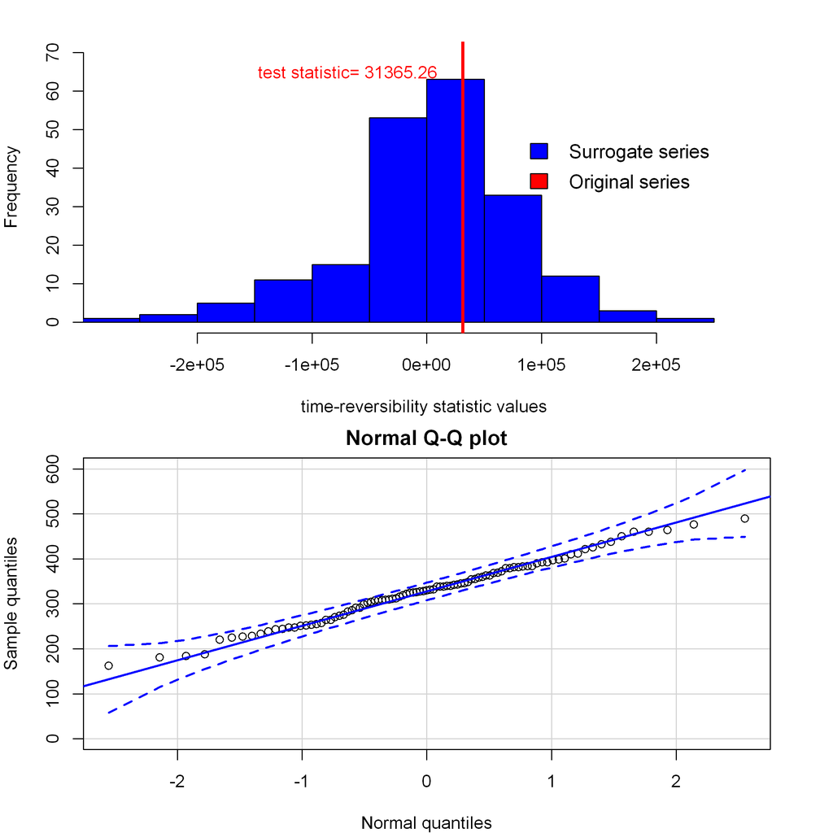

```r
par(mar=c(4,4,2,3),mfrow=c(2,1))

hist(st_demand$surrogates.statistics,col="blue",xlab="time-reversibility statistic values ",ylim=c(0,70),
     main="",
     xlim=c(min(st_demand$surrogates.statistics),-min(st_demand$surrogates.statistics)))
abline(v=st_demand$data.statistic,col="red",lwd=3,lty=1)
text(st_demand$data.statistic-1e5,65,paste("test statistic=",round(st_demand$data.statistic,2)),col="red")


text <- c("Surrogate series","Original series")
legend_order <- matrix(1:2,ncol=1,byrow = T)
legend(x = st_demand$data.statistic+40000,y=60,legend = text[legend_order],
       col=c("blue","red"),ncol=1, cex=1.1,title="",bty="n",
             fill=c("blue","red"),text.width = strwidth(text)[1]*1.80)

#Normality plot
qqPlot(demand,main="Normal Q-Q plot",ylab="Sample quantiles",xlab="Normal quantiles",ylim=c(0,600),id=F)
```

# Nonlinear Time series Analysis

Ref: H. Kantz and T. Schreiber:(Cambridge university press)

The original time.series from which the surrogate data is generated.

Details This function runs a set of nonlinearity tests implemented by this and other R packages, including:

• Teraesvirta’s neural metwork test for nonlinearity (terasvirta.test).

• White neural metwork test for nonlinearity (white.test).

• Keenan’s one-degree test for nonlinearity (keenanTest).

• Perform the McLeod-Li test for conditional heteroscedascity (ARCH). (mcleodLiTest).

• Perform the Tsay’s test for quadratic nonlinearity in a time series. (tsayTest).

• Perform the Likelihood ratio test for threshold nonlinearity. (thresholdTest).

```r
nonlinearityTest(demand,verbose=T)$Terasvirta
```

```
		 ** Teraesvirta's neural network test  **
		 Null hypothesis: Linearity in "mean"
		 X-squared =  0.6477426  df =  2  p-value =  0.7233433

		 ** White neural network test  **
		 Null hypothesis: Linearity in "mean"
		 X-squared =  0.7631819  df =  2  p-value =  0.6827743

		 ** Keenan's one-degree test for nonlinearity  **
		 Null hypothesis: The time series follows some AR process
		 F-stat =  0.0063361  p-value =  0.9367344

		 ** McLeod-Li test  **
		 Null hypothesis: The time series follows some ARIMA process
		 Maximum p-value =  8.924017e-11

		 ** Tsay's Test for nonlinearity **
		 Null hypothesis: The time series follows some AR process
		 F-stat =  0.006341447  p-value =  0.9367078

		 ** Likelihood ratio test for threshold nonlinearity **
		 Null hypothesis: The time series follows some AR process
		 Alternativce hypothesis: The time series follows some TAR process
		 X-squared =  3.160917  p-value =  0.3005757
```

```
	Teraesvirta Neural Network Test

data:  ts(time.series)
X-squared = 0.64774, df = 2, p-value = 0.7233
```

# Fitting the Machine learning algorithms and ARIMA model with rolling-origin out-of-sample forecast/backcast evaluations (update and recalibration).

The impact of those parameters on the final accuracy should be assessed by adopting an out-of-sample rolling strategy (see Tashman paper: https://www.researchgate.net/publication/247087596_Out-of_sample_tests_of_forecasting_accuracy_an_analysis_and_review

Recalibration used here suggests that whenever the forecasting origin (the final time period of the training series) is updated, the time series model is refitted/model parameters re-estimated/new forecasting equation obtained.

Rolling-origin evaluation for $h$ (18-month) steps-ahead forecast suggests that you will consider $M \leq h$ different sets of forecasts or $M$ different forecast equations

# **Rolling-origin forecast evaluation for ARIMA model (baseline model)**

```r
setwd("C:/Users/user/Desktop/PhD Documents Cardiff_main/PhD Project Chapter 1-6/LATEX PhD Thesis 1/LaTex Files _PhD/Juliet Publication work_Main/Current-Resubmission_IJF_2021/R Scripts")

#script for ARIMA backcasting
source("reverse-ARIMA-forecast-script.r")

#Script of functions for rolling-origin evaluation for ARIMA model (forecasts & backcasts)
source("rolling-eval-ARIMA-script.r")
```

```r
# 18-month forecast based on STL with KS-BSM corrected data
options(warn=-1)
ARIMA_results_forecasts<- ro_eval_ARIMA_forecast(series=demand,forecast_length=18)
```

# Forecast: Comparing estimated errors at the different lead times (ARIMA model)

```r
setwd("C:/Users/user/Desktop/PhD Documents Cardiff_main/PhD Project Chapter 1-6/LATEX PhD Thesis 1/LaTex Files _PhD/Juliet Publication work_Main/Current-Resubmission_IJF_2021")
# 18-month rolling-origin evaluation with update and recalibration

ARIMA_results_forecasts$ARIMA_errors
write.csv(ARIMA_results_forecasts$ARIMA_errors,"ARIMA_results_forecasts_ARIMA_errors.csv")
```

A data.frame: 17 × 3

|  | RMSE <dbl> | MAE <dbl> | MAPE <dbl> |
| --- | --- | --- | --- |
| Mar 2019 | 63.32722 | 51.67801 | 18.70766 |
| Apr 2019 | 63.98916 | 53.16040 | 19.17838 |
| May 2019 | 85.80101 | 73.52315 | 27.50176 |
| Jun 2019 | 65.70371 | 53.70435 | 20.33378 |
| Jul 2019 | 63.81077 | 53.46870 | 20.07882 |
| Aug 2019 | 79.28973 | 65.53343 | 25.41523 |
| Sep 2019 | 56.66492 | 48.73048 | 18.39892 |
| Oct 2019 | 47.38661 | 41.10026 | 13.75477 |
| Nov 2019 | 51.06854 | 44.31391 | 14.34997 |
| Dec 2019 | 58.29633 | 50.72236 | 15.84847 |
| Jan 2020 | 47.60768 | 39.90712 | 14.13547 |
| Feb 2020 | 51.21722 | 44.62161 | 16.03769 |
| Mar 2020 | 63.07886 | 50.92786 | 19.84065 |
| Apr 2020 | 53.61965 | 47.65220 | 18.28367 |
| May 2020 | 51.39123 | 46.27240 | 15.87028 |
| Jun 2020 | 52.64034 | 45.94790 | 17.73866 |
| Jul 2020 | 72.54333 | 68.61710 | 27.65689 |

```r
# 18-month rolling-origin evaluation with update and recalibration
ARIMA_results_forecasts$ARIMA_model[[1]]
```

```
Series: train_series
ARIMA(0,1,3)

Coefficients:
          ma1      ma2      ma3
      -0.3784  -0.0478  -0.2512
s.e.   0.1129   0.1287   0.1099

sigma^2 estimated as 2275:  log likelihood=-389.73
AIC=787.46   AICc=788.04   BIC=796.68
```

# Rolling-origin backcast evaluation for ARIMA model (baseline model)

```r
# 18-month backcasts based on STL with KS-BSM corrected data
ARIMA_results_backcasts<- ro_eval_ARIMA_backcast(series=demand,backcast_length=18)
```

# Backcast: Comparing estimated errors at the different lead times (ARIMA model)

```r
setwd("C:/Users/user/Desktop/PhD Documents Cardiff_main/PhD Project Chapter 1-6/LATEX PhD Thesis 1/LaTex Files _PhD/Juliet Publication work_Main/Current-Resubmission_IJF_2021")

# 18-month rolling-origin evaluation with update and recalibration
ARIMA_results_backcasts$ARIMA_errors
write.csv(ARIMA_results_backcasts$ARIMA_errors,"ARIMA_results_backcasts_ARIMA_errors.csv")
```

A data.frame: 17 × 3

|  | RMSE <dbl> | MAE <dbl> | MAPE <dbl> |
| --- | --- | --- | --- |
| Jun 2014 | 55.37172 | 46.37660 | 20.25885 |
| May 2014 | 86.13057 | 69.52243 | 31.65644 |
| Apr 2014 | 58.39066 | 49.43957 | 21.84207 |
| Mar 2014 | 60.19469 | 51.39555 | 22.81086 |
| Feb 2014 | 61.11560 | 53.57588 | 23.79025 |
| Jan 2014 | 61.67444 | 53.54781 | 23.70290 |
| Dec 2013 | 66.76411 | 57.08763 | 26.02322 |
| Nov 2013 | 67.86257 | 61.70262 | 27.30137 |
| Oct 2013 | 69.50379 | 62.95459 | 28.62577 |
| Sep 2013 | 70.33322 | 62.20784 | 29.21952 |
| Aug 2013 | 85.19080 | 77.73069 | 36.56287 |
| Jul 2013 | 90.30637 | 80.53764 | 39.78656 |
| Jun 2013 | 99.12978 | 92.51916 | 45.64137 |
| May 2013 | 83.53227 | 74.28985 | 39.12589 |
| Apr 2013 | 89.62022 | 83.52418 | 44.88734 |
| Mar 2013 | 94.29129 | 87.41335 | 48.79613 |
| Feb 2013 | 102.99333 | 101.07468 | 58.92206 |

```r
# 12-month rolling-origin evaluation with update and recalibration
#based on STL with KS-BSM corrected data (best)
ARIMA_results_backcasts$ARIMA_model[[1]]
```

```
Series: train_series
ARIMA(0,1,2)

Coefficients:
          ma1      ma2
      -0.4044  -0.3003
s.e.   0.1045   0.0963

sigma^2 estimated as 2574:  log likelihood=-394.86
AIC=795.71   AICc=796.06   BIC=802.63
```

```r
#ARIMA_results_backcasts$ARIMA_backcast[[1]]
```

# ARIMA forecast & backcast autoplots

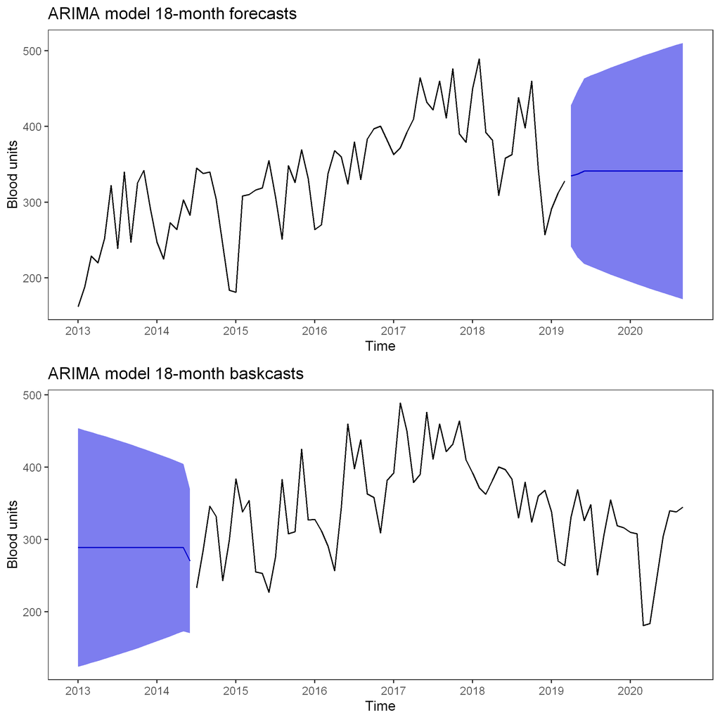

```r
p1=autoplot(ARIMA_results_forecasts$ARIMA_forecast[[1]])+
ggtitle("ARIMA model 18-month forecasts")+labs(y="Blood units")+
    scale_x_continuous(breaks=c(2013,2014,2015,2016,2017,2018, 2019,2020),
        labels=c("2013","2014","2015","2016","2017","2018","2019","2020"))+ theme_bw()+
theme(panel.grid.major = element_blank(), panel.grid.minor = element_blank(),
panel.background = element_blank())


p3=autoplot(ARIMA_results_backcasts$ARIMA_backcast[[1]])+
ggtitle("ARIMA model 18-month baskcasts")+labs(y="Blood units")+
    scale_x_continuous(breaks=c(2013,2014,2015,2016,2017,2018, 2019,2020),
        labels=c("2013","2014","2015","2016","2017","2018","2019","2020"))+ theme_bw()+
theme(panel.grid.major = element_blank(), panel.grid.minor = element_blank(),
panel.background = element_blank())


grid.arrange(p1,p3,nrow=2,ncol=1)
```

# Fitting 6 Machine Learning Algorithms for the blood demand data

**The 6 machine learning methods used were:**

K-Nearest Neighbor regression (KNN)

Neural Network Auto-Regressive (NNAR)

Generalized Regression Neural Network (GRNN)

Multi-Layer Perceptron (MLP) neural networks

Extreme learning machines (ELM) neural networks

Long short-term memory (LSTM) neural network.

**Backcasting documents**

https://otexts.com/fpp2/backcasting.html

General information about Backcasting: https://en.wikipedia.org/wiki/Backcasting

https://otexts.com/fpp2/long-short-ts.html

Backcasting theory: https://ec.europa.eu/eurostat/documents/3888793/5838209/KS-DT-05-029-EN.PDF.pdf/9cb16268-6479-4014-8a0c-68606e772a2f?t=1414779282000

Backcast formula: https://support.numxl.com/hc/en-us/articles/360032880331-Backward-Forecast

When it comes to deep learning models, there is a large space for hyperparameters to be defined and the results are heavily depending on these hyperparameters, such as the optimal number of layers, the optimal number of nodes in each layer, the suitable activation function, the suitable loss function, the best optimizer, the best regularization techniques, the best random initialization , …etc. Unfortunately, we do not have yet an exact rule to decide about these hyperparameters, and they depend on the problem under study, the data at hand, and the experience of the modeler.

# (Machine Learning): Time Series Forecasting with KNN via Multiple Input Multiple Output (MIMO) strategy - Model 1

In order to specify a KNN model the user has to select, among other things, the value of the k parameter. Several strategies can be used to choose this value. A first, fast, straightforward solution is to use some heuristic (it is recommended setting k to the square root of the number of training examples). Other approach is to select k using an optimization tool on a validation set. k should minimize a forecast accuracy measure. The optimization strategy is very time consuming.

A third strategy is to use several KNN models with different k values. Each KNN model generates its forecasts and the forecasts of the different models are averaged to produce the final forecast. This strategy is based on the success of model combination in time series forecasting. This way, the use of a time consuming optimization tool is avoided and the forecasts are not based on an unique, heuristic k value. In our package you can use of this strategy specifying a vector of k values:

https://www.r-bloggers.com/2020/03/grid-search-and-bayesian-hyperparameter-optimization-using-tune-and-caret-packages/

# **Rolling-origin forecast evaluation for KNN model**

```r
setwd("C:/Users/user/Desktop/PhD Documents Cardiff_main/PhD Project Chapter 1-6/LATEX PhD Thesis 1/LaTex Files _PhD/Juliet Publication work_Main/Current-Resubmission_IJF_2021/R Scripts")

#Script of the function to choose k and the lag value which results in minimum RMSE
#or better forecasts & backcasts
source("KNN-k-lag-best-script.r")

#Script of the function for rolling-origin forecast evaluations for the KNN model
source("ro-eval-KNN-script.r")
```

```r
# 18-month forecast
KNN_results_forecasts<- ro_eval_KNN_forecast(series=demand,forecast_length=18)
```

# Forecast: Comparing estimated errors at the different lead times (KNN model)

```r
setwd("C:/Users/user/Desktop/PhD Documents Cardiff_main/PhD Project Chapter 1-6/LATEX PhD Thesis 1/LaTex Files _PhD/Juliet Publication work_Main/Current-Resubmission_IJF_2021")

KNN_results_forecasts$KNN_errors
write.csv(KNN_results_forecasts$KNN_errors,"KNN_results_forecasts_KNN_errors.csv")
```

A data.frame: 17 × 3

|  | RMSE <dbl> | MAE <dbl> | MAPE <dbl> |
| --- | --- | --- | --- |
| Mar 2019 | 55.20126 | 43.73491 | 14.813436 |
| Apr 2019 | 56.55358 | 45.02150 | 15.291528 |
| May 2019 | 49.87554 | 40.29117 | 14.472149 |
| Jun 2019 | 53.17746 | 40.92901 | 15.047113 |
| Jul 2019 | 55.02768 | 43.49536 | 16.005952 |
| Aug 2019 | 56.88864 | 47.76424 | 17.531176 |
| Sep 2019 | 51.50125 | 45.52867 | 16.304061 |
| Oct 2019 | 47.77602 | 37.38139 | 11.944807 |
| Nov 2019 | 43.12127 | 37.14633 | 12.411718 |
| Dec 2019 | 46.99301 | 36.63728 | 12.034906 |
| Jan 2020 | 43.06744 | 33.66396 | 11.421057 |
| Feb 2020 | 48.25874 | 36.96893 | 12.547296 |
| Mar 2020 | 35.72058 | 27.63258 | 10.602618 |
| Apr 2020 | 36.00957 | 28.06667 | 10.924279 |
| May 2020 | 28.89529 | 24.62500 | 8.186631 |
| Jun 2020 | 26.30625 | 24.64503 | 9.296213 |
| Jul 2020 | 49.57220 | 38.75000 | 16.319392 |

# Rolling-origin backcast evaluation for KNN model

```r
# 18-month backcast
KNN_results_backcasts<- ro_eval_KNN_backcast(series=demand,backcast_length=18)
```

# Backcast: Comparing estimated errors at the different lead times (KNN model)

```r
setwd("C:/Users/user/Desktop/PhD Documents Cardiff_main/PhD Project Chapter 1-6/LATEX PhD Thesis 1/LaTex Files _PhD/Juliet Publication work_Main/Current-Resubmission_IJF_2021")

KNN_results_backcasts$KNN_errors
write.csv(KNN_results_backcasts$KNN_errors,"KNN_results_backcasts_KNN_errors.csv")
```

A data.frame: 17 × 3

|  | RMSE <dbl> | MAE <dbl> | MAPE <dbl> |
| --- | --- | --- | --- |
| Jun 2014 | 81.67151 | 69.94764 | 29.978155 |
| May 2014 | 70.35998 | 56.12036 | 24.471187 |
| Apr 2014 | 72.52498 | 59.56538 | 25.980009 |
| Mar 2014 | 79.91868 | 57.56494 | 27.008543 |
| Feb 2014 | 81.36028 | 65.57691 | 30.674636 |
| Jan 2014 | 70.59693 | 54.84668 | 25.225586 |
| Dec 2013 | 61.24152 | 45.83201 | 20.321185 |
| Nov 2013 | 69.77867 | 61.81829 | 25.485516 |
| Oct 2013 | 63.64058 | 54.99983 | 25.936972 |
| Sep 2013 | 77.36263 | 60.16835 | 29.842539 |
| Aug 2013 | 79.44816 | 60.12443 | 30.515221 |
| Jul 2013 | 72.50035 | 55.85650 | 27.435929 |
| Jun 2013 | 51.08490 | 37.66667 | 16.412945 |
| May 2013 | 73.03424 | 54.80000 | 29.008306 |
| Apr 2013 | 43.75500 | 30.50000 | 14.647023 |
| Mar 2013 | 14.16569 | 12.66667 | 6.802091 |
| Feb 2013 | 42.54409 | 39.00000 | 21.683740 |

**Choice of hyperparameter K at different lag values for forecasting (first 9 lead times for example out of the 17 lead times)**

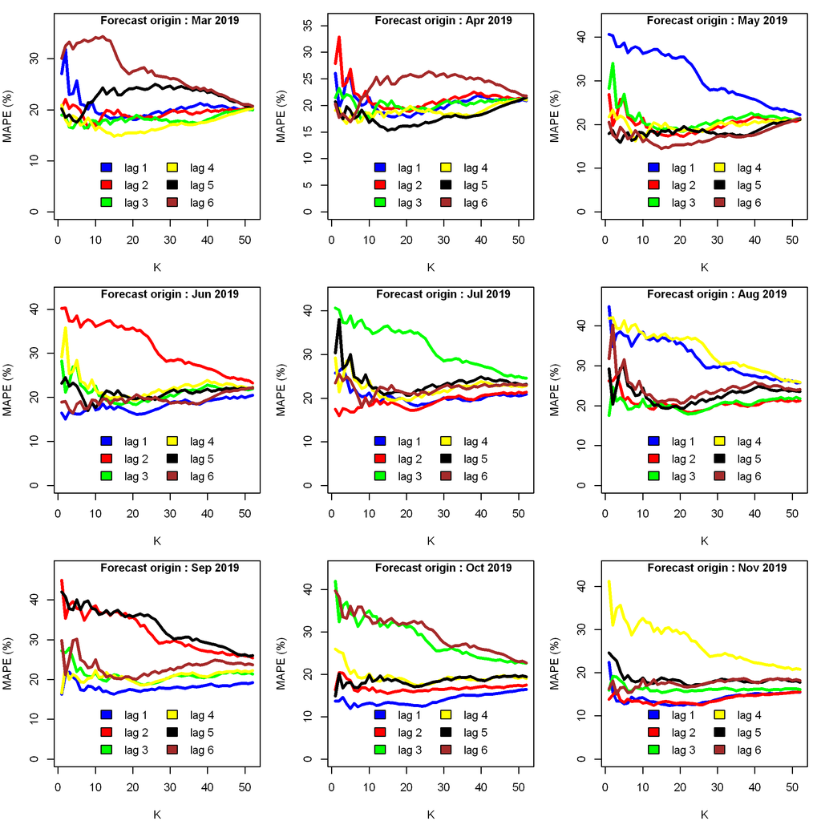

```r
forecast_origins<-rownames(KNN_results_forecasts$KNN_errors)
par(mfrow=c(3,3),mar=c(4,4,1,1))
k_values<- 52
lead_times<- 1:9
lwd_width<-3
for(i in lead_times){
    plot(1:k_values,KNN_results_forecasts$k_best[[i]][1,],type="l",xlab="K",xlim=c(1,k_values),
         ylab="MAPE (%)",col="blue",ylim=c(0,max(KNN_results_forecasts$k_best[[i]])+3),lwd=lwd_width)

        legend("bottom",c("lag 1","lag 2" ,"lag 3","lag 4","lag 5","lag 6"),
         col=c("blue","red","green","yellow","black","brown"),bty="n",cex=1,box.lwd = 2,
           fill=c("blue","red","green","yellow","black","brown"),horiz=F,ncol=2)

    lines(1:k_values,KNN_results_forecasts$k_best[[i]][2,],col="red",type="l",lwd=lwd_width)
    lines(1:k_values,KNN_results_forecasts$k_best[[i]][3,],col="green",type="l",lwd=lwd_width)
    lines(1:k_values,KNN_results_forecasts$k_best[[i]][4,],col="yellow",type="l",lwd=lwd_width)
    lines(1:k_values,KNN_results_forecasts$k_best[[i]][5,],col="black",type="l",lwd=lwd_width)
    lines(1:k_values,KNN_results_forecasts$k_best[[i]][6,],col="brown",type="l",lwd=lwd_width)

    text(30,max(KNN_results_forecasts$k_best[[i]])+3,paste("Forecast origin",":",forecast_origins[i]),col="black",
        font=2)
    }
```

**Choice of hyperparameter K at different lag values for backcasting (first 9 lead times for example out of the 17 lead times)**

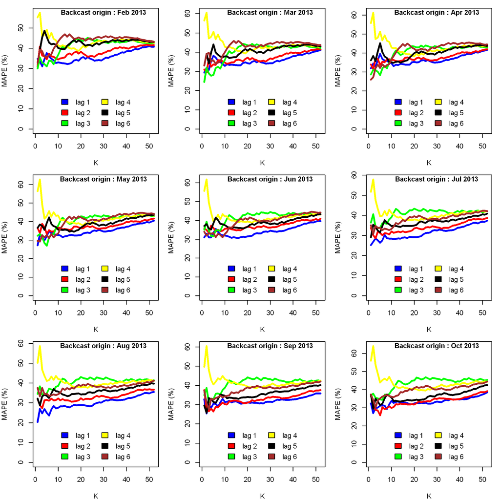

```r
backcast_origins<- rev(rownames(KNN_results_backcasts$KNN_errors))
par(mfrow=c(3,3),mar=c(4,4,1,1))
k_values<- 52
lead_times<- 1:9
lwd_width<-3
for(i in lead_times){
    plot(1:k_values,KNN_results_backcasts$k_best[[i]][1,],type="l",xlab="K",xlim=c(1,k_values),
         ylab="MAPE (%)",col="blue",ylim=c(0,max(KNN_results_backcasts$k_best[[i]])),lwd=lwd_width)

        legend("bottom",c("lag 1","lag 2" ,"lag 3","lag 4","lag 5","lag 6"),
         col=c("blue","red","green","yellow","black","brown"),bty="n",cex=1,box.lwd = 2,
           fill=c("blue","red","green","yellow","black","brown"),horiz=F,ncol=2)

    lines(1:k_values,KNN_results_backcasts$k_best[[i]][2,],col="red",type="l",lwd=lwd_width)
    lines(1:k_values,KNN_results_backcasts$k_best[[i]][3,],col="green",type="l",lwd=lwd_width)
    lines(1:k_values,KNN_results_backcasts$k_best[[i]][4,],col="yellow",type="l",lwd=lwd_width)
    lines(1:k_values,KNN_results_backcasts$k_best[[i]][5,],col="black",type="l",lwd=lwd_width)
    lines(1:k_values,KNN_results_backcasts$k_best[[i]][6,],col="brown",type="l",lwd=lwd_width)
     text(30,max(KNN_results_backcasts$k_best[[i]]),paste("Backcast origin",":",backcast_origins[i]),col="black",
        font=2)
    }
```

# KNN forecast autoplots

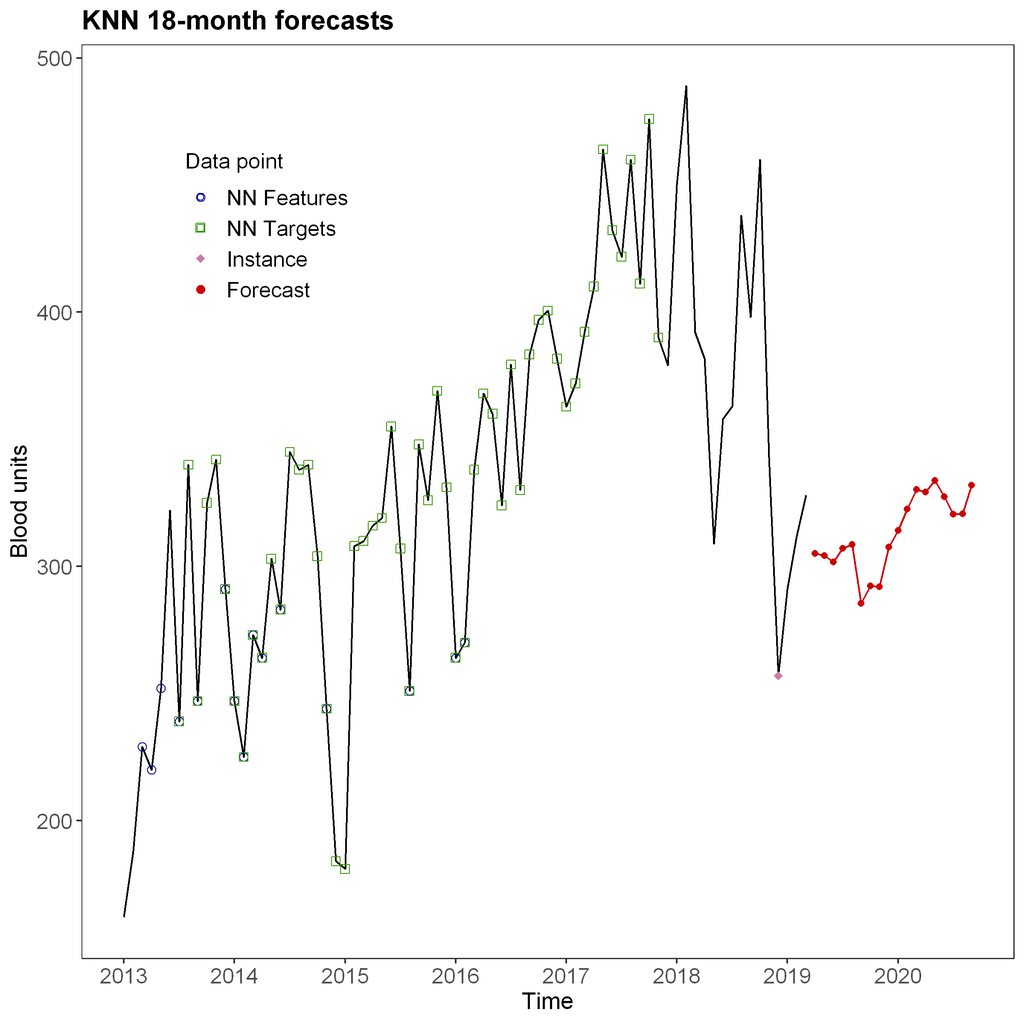

```r
KNN1<-autoplot(KNN_results_forecasts$KNN_Model[[1]], highlight = "neighbors", faceting =FALSE)+
ggtitle("KNN 18-month forecasts")+ theme_bw()+
theme(panel.grid.major = element_blank(), panel.grid.minor = element_blank(),
panel.background = element_blank(),legend.position=c(0.2, .8))+labs(y="Blood units")+
theme(plot.title = element_text(hjust=0), axis.text.x = element_text(size = 12)
        ,axis.text.y = element_text(size = 12), axis.title.x = element_text(size = 13), axis.title.y = element_text(size = 13))+
theme(plot.title = element_text(size = 12, face = "bold"),
    legend.title=element_text(size=12),
    legend.text=element_text(size=12))+ scale_x_continuous(breaks=c(2013,2014,2015,2016,2017,2018, 2019,2020),
        labels=c("2013","2014","2015","2016","2017","2018","2019","2020"))

KNN1+ theme(plot.title = element_text(size=15))
```

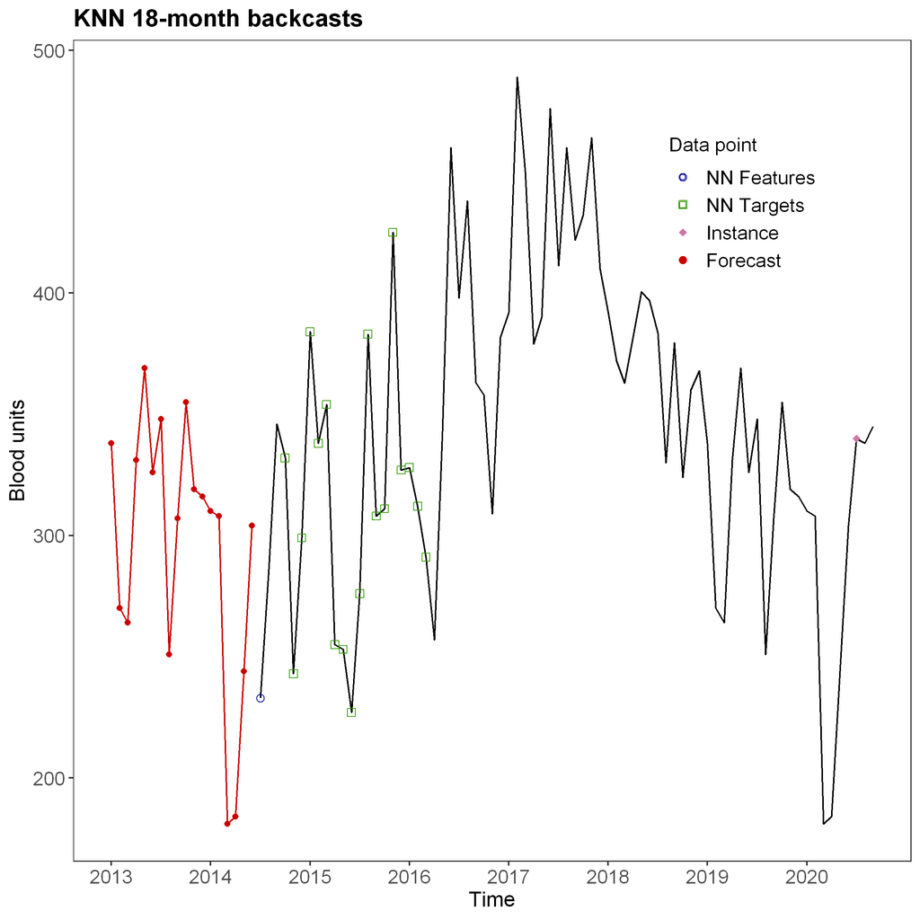

```r
options(warn=-1)
KNN3=autoplot(KNN_results_backcasts$KNN_Model[[1]], highlight = "neighbors", faceting =F)+
ggtitle("KNN 18-month backcasts")+theme_bw()+
theme(panel.grid.major = element_blank(), panel.grid.minor = element_blank(),
panel.background = element_blank(),legend.position=c(0.8, .8))+labs(y="Blood units")+ theme(plot.title = element_text(hjust=0), axis.text.x = element_text(size = 12)
        ,axis.text.y = element_text(size = 12), axis.title.x = element_text(size = 13), axis.title.y = element_text(size = 13))+
theme(plot.title = element_text(size = 12, face = "bold"),
    legend.title=element_text(size=12),
    legend.text=element_text(size=12))+ scale_x_continuous(breaks=c(2013,2014,2015,2016,2017,2018, 2019,2020),
        labels=c("2013","2014","2015","2016","2017","2018","2019","2020"))

KNN3+ theme(plot.title = element_text(size=15))
```

# MODEL 2 (Machine Learning): Neural Network Time Series Forecasts

The fitted model is denoted as an NNAR(p,k) model, where k is the number of hidden nodes. This is analogous to an AR(p) model but with nonlinear functions. For seasonal data, the fitted model is called an NNAR(p,P,k)[m] model, which is analogous to an ARIMA(p,0,0)(P,0,0)[m] model but with nonlinear functions

**Neural Network Auto-Regressive (NNAR)**

https://rstudio-pubs-static.s3.amazonaws.com/313595_2cd55f37d9214b15ab60d7b1a0663da8.html

https://pkg.robjhyndman.com/forecast/reference/nnetar.html

```r
setwd("C:/Users/user/Desktop/PhD Documents Cardiff_main/PhD Project Chapter 1-6/LATEX PhD Thesis 1/LaTex Files _PhD/Juliet Publication work_Main/Current-Resubmission_IJF_2021/R Scripts")

#script of functions for choosing the non-seasonal lag (p) and the average number of networks
#for the NNAR model forecasts & backcasting based on mimimum MAPE
source("NNAR-tuning-script.r")

#script of functions for rolling-origin forecast & backcast evaluations for the NNAR model
source("ro-eval-NNAR-script.r")
```

# Rolling-origin forecast evaluation for NNAR model

```r
# 18-month forecast
NNAR_results_forecasts<- ro_eval_NNAR_forecast(series=demand,forecast_length=18,seed.number=1)
```

# Forecast: Comparing estimated errors at the different lead times (NNAR model)

```r
setwd("C:/Users/user/Desktop/PhD Documents Cardiff_main/PhD Project Chapter 1-6/LATEX PhD Thesis 1/LaTex Files _PhD/Juliet Publication work_Main/Current-Resubmission_IJF_2021")

NNAR_results_forecasts$NNAR_errors
write.csv(NNAR_results_forecasts$NNAR_errors,"NNAR_results_forecasts_NNAR_errors.csv")
```

A data.frame: 17 × 3

|  | RMSE <dbl> | MAE <dbl> | MAPE <dbl> |
| --- | --- | --- | --- |
| Mar 2019 | 54.12339 | 44.21387 | 14.15618 |
| Apr 2019 | 55.48016 | 45.82533 | 14.52124 |
| May 2019 | 93.83094 | 80.46898 | 30.06379 |
| Jun 2019 | 60.35739 | 49.76127 | 18.53110 |
| Jul 2019 | 59.75395 | 51.18262 | 18.84419 |
| Aug 2019 | 91.71662 | 78.42168 | 30.15165 |
| Sep 2019 | 55.36718 | 47.12111 | 17.59428 |
| Oct 2019 | 50.47436 | 42.41989 | 14.52992 |
| Nov 2019 | 53.52436 | 45.78859 | 15.52347 |
| Dec 2019 | 56.11419 | 47.59655 | 16.44479 |
| Jan 2020 | 47.03282 | 40.34634 | 14.03651 |
| Feb 2020 | 55.84141 | 47.21863 | 17.34065 |
| Mar 2020 | 94.97767 | 85.46768 | 32.26531 |
| Apr 2020 | 55.16968 | 48.00475 | 18.54220 |
| May 2020 | 56.82611 | 51.29757 | 17.63394 |
| Jun 2020 | 57.10363 | 51.50178 | 19.55863 |
| Jul 2020 | 76.76705 | 73.42016 | 29.48267 |

# Rolling-origin backcast evaluation for NNAR model

```r
# 18-month backcast
NNAR_results_backcasts<- ro_eval_NNAR_backcast(series=demand,backcast_length=18,seed.number=1)
```

# Backcast: Comparing estimated errors at the different lead times (NNAR model)

```r
setwd("C:/Users/user/Desktop/PhD Documents Cardiff_main/PhD Project Chapter 1-6/LATEX PhD Thesis 1/LaTex Files _PhD/Juliet Publication work_Main/Current-Resubmission_IJF_2021")

NNAR_results_backcasts$NNAR_errors
write.csv(NNAR_results_backcasts$NNAR_errors,"NNAR_results_backcasts_NNAR_errors.csv")
```

A data.frame: 17 × 3

|  | RMSE <dbl> | MAE <dbl> | MAPE <dbl> |
| --- | --- | --- | --- |
| Jun 2014 | 81.52591 | 63.05264 | 28.90144 |
| May 2014 | 84.34812 | 69.89058 | 31.56123 |
| Apr 2014 | 83.93541 | 65.87656 | 30.54317 |
| Mar 2014 | 85.12004 | 66.98761 | 31.25024 |
| Feb 2014 | 84.27195 | 67.56726 | 31.57071 |
| Jan 2014 | 84.51096 | 66.03069 | 31.10897 |
| Dec 2013 | 86.30820 | 70.80010 | 32.88898 |
| Nov 2013 | 85.34665 | 74.22393 | 33.95949 |
| Oct 2013 | 82.73118 | 72.63060 | 33.90067 |
| Sep 2013 | 84.00905 | 73.03879 | 34.89090 |
| Aug 2013 | 89.20837 | 79.97265 | 38.16909 |
| Jul 2013 | 85.97250 | 76.34005 | 37.96859 |
| Jun 2013 | 91.97756 | 83.73656 | 41.93459 |
| May 2013 | 93.35992 | 85.31873 | 44.49428 |
| Apr 2013 | 101.04314 | 95.86487 | 51.15427 |
| Mar 2013 | 111.11353 | 92.75426 | 53.47608 |
| Feb 2013 | 112.42436 | 103.15563 | 61.18119 |

# Forecast & Backcast Autoplots (NNAR model)

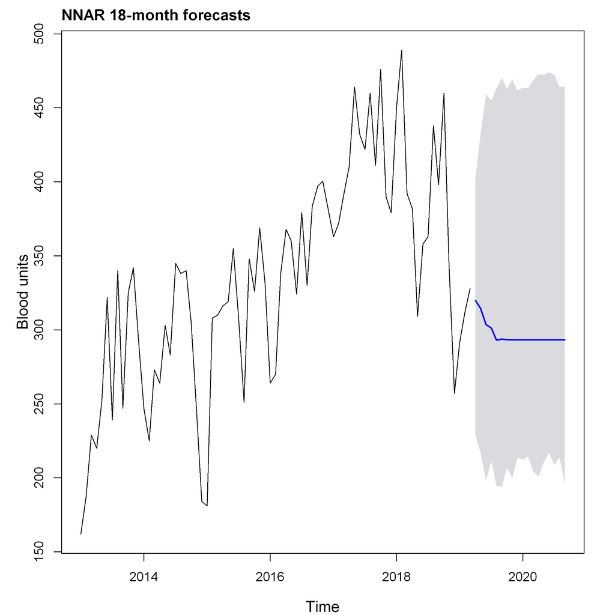

```r
par(mar=c(4,4,2,2))
plot(NNAR_results_forecasts$NNAR_forecasts[[1]],main="")
mtext(text = "Blood units",
      side = 2, #side 2 = left
      line = 2,cex=1.2)

mtext(text = "Time",
      side = 1, #side 2 = left
      line = 3,cex=1.2)


mtext(text = "NNAR 18-month forecasts",
      side = 3, #side 2 = left
      line = 0.5,cex=1.2,font=2,adj =0)
```

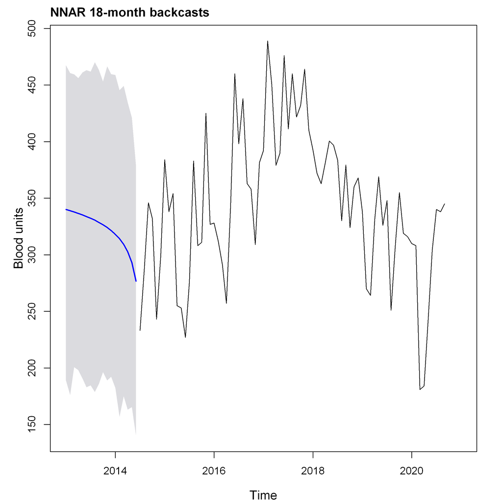

```r
par(mar=c(4,4,2,2))
plot(NNAR_results_backcasts$NNAR_backcasts[[1]],main="",xlim=c(2013,2021))
mtext(text = "Blood units",
      side = 2, #side 2 = left
      line = 2,cex=1.2)

mtext(text = "Time",
      side = 1, #side 2 = left
      line = 3,cex=1.2)

mtext(text = "NNAR 18-month backcasts",
      side = 3, #side 2 = left
      line = 0.5,cex=1.2,font=2,adj =0)
```

# MODEL 3 (Machine Learning):Generalized Regression Neural Networks

https://cran.r-project.org/web/packages/tsfgrnn/vignettes/tsfgrnn.html

```r
#setting a working directory
setwd("C:/Users/user/Desktop/PhD Documents Cardiff_main/PhD Project Chapter 1-6/LATEX PhD Thesis 1/LaTex Files _PhD/Juliet Publication work_Main/Current-Resubmission_IJF_2021/R Scripts")

#script of functions for choosing the lags used as autoregressive variables
#for the GRNN model forecasts & backcasting based on mimimum MAPE
#The smooting parameter is automatically chosen via optimisation
source("GRNN-lag-best-script.r")

#Script of the function for rolling-origin forecast evaluations for the GRNN model
source("ro-eval-GRNN-script.r")

#Script of function for GRNN autoplots (backcast and forecast)
source("autoplot-GRNN-script.r")
```

```r
# 18-month forecast
GRNN_results_forecasts<- ro_eval_GRNN_forecast(series=demand,forecast_length=18)
```

# Forecast: Comparing estimated errors at the different lead times (GRNN model)

```r
setwd("C:/Users/user/Desktop/PhD Documents Cardiff_main/PhD Project Chapter 1-6/LATEX PhD Thesis 1/LaTex Files _PhD/Juliet Publication work_Main/Current-Resubmission_IJF_2021")

GRNN_results_forecasts$GRNN_errors
write.csv(GRNN_results_forecasts$GRNN_errors,"GRNN_results_forecasts_GRNN_errors.csv")
```

A data.frame: 17 × 3

|  | RMSE <dbl> | MAE <dbl> | MAPE <dbl> |
| --- | --- | --- | --- |
| Mar 2019 | 59.96103 | 49.10685 | 17.36633 |
| Apr 2019 | 64.38693 | 53.15042 | 19.12691 |
| May 2019 | 64.50192 | 53.50918 | 20.04870 |
| Jun 2019 | 63.26720 | 51.95294 | 19.59128 |
| Jul 2019 | 64.93461 | 54.03565 | 20.39217 |
| Aug 2019 | 68.53831 | 55.95960 | 21.69252 |
| Sep 2019 | 63.70145 | 52.00517 | 20.12052 |
| Oct 2019 | 50.63870 | 41.71664 | 15.21737 |
| Nov 2019 | 55.06770 | 44.66615 | 16.38741 |
| Dec 2019 | 48.26857 | 42.12274 | 14.41420 |
| Jan 2020 | 57.88749 | 45.30984 | 16.71129 |
| Feb 2020 | 61.62303 | 49.90497 | 18.54756 |
| Mar 2020 | 62.47469 | 47.68374 | 18.90684 |
| Apr 2020 | 62.48696 | 48.85752 | 19.56423 |
| May 2020 | 56.14489 | 44.57498 | 17.03041 |
| Jun 2020 | 74.12113 | 56.64391 | 22.59512 |
| Jul 2020 | 75.33465 | 68.20870 | 27.83351 |

# Rolling-origin backcast evaluation for GRNN model

```r
# 18-month backcast
GRNN_results_backcasts<- ro_eval_GRNN_backcast(series=demand,backcast_length=18)
```

# Backcast: Comparing estimated errors at the different lead times (GRNN model)

```r
setwd("C:/Users/user/Desktop/PhD Documents Cardiff_main/PhD Project Chapter 1-6/LATEX PhD Thesis 1/LaTex Files _PhD/Juliet Publication work_Main/Current-Resubmission_IJF_2021")

GRNN_results_backcasts$GRNN_errors
write.csv(GRNN_results_backcasts$GRNN_errors,"GRNN_results_backcasts_GRNN_errors.csv")
```

A data.frame: 17 × 3

|  | RMSE <dbl> | MAE <dbl> | MAPE <dbl> |
| --- | --- | --- | --- |
| Jun 2014 | 86.91492 | 68.41959 | 31.11359 |
| May 2014 | 88.70881 | 72.21077 | 32.79907 |
| Apr 2014 | 88.41552 | 71.47474 | 32.82860 |
| Mar 2014 | 75.50435 | 60.20684 | 27.68062 |
| Feb 2014 | 60.03920 | 53.13189 | 23.41806 |
| Jan 2014 | 58.82439 | 51.04644 | 22.37832 |
| Dec 2013 | 60.24255 | 54.22737 | 23.74708 |
| Nov 2013 | 63.49280 | 57.53398 | 24.99606 |
| Oct 2013 | 64.69358 | 59.61154 | 26.61153 |
| Sep 2013 | 62.14446 | 54.62469 | 25.69678 |
| Aug 2013 | 69.52387 | 64.27883 | 29.68047 |
| Jul 2013 | 65.04996 | 56.02369 | 28.13701 |
| Jun 2013 | 68.42878 | 61.17085 | 30.79467 |
| May 2013 | 74.44741 | 68.31333 | 35.59684 |
| Apr 2013 | 86.81759 | 82.88286 | 44.11447 |
| Mar 2013 | 96.47454 | 92.24378 | 50.83645 |
| Feb 2013 | 108.49579 | 105.19202 | 61.57741 |

# GRNN forecast autoplots

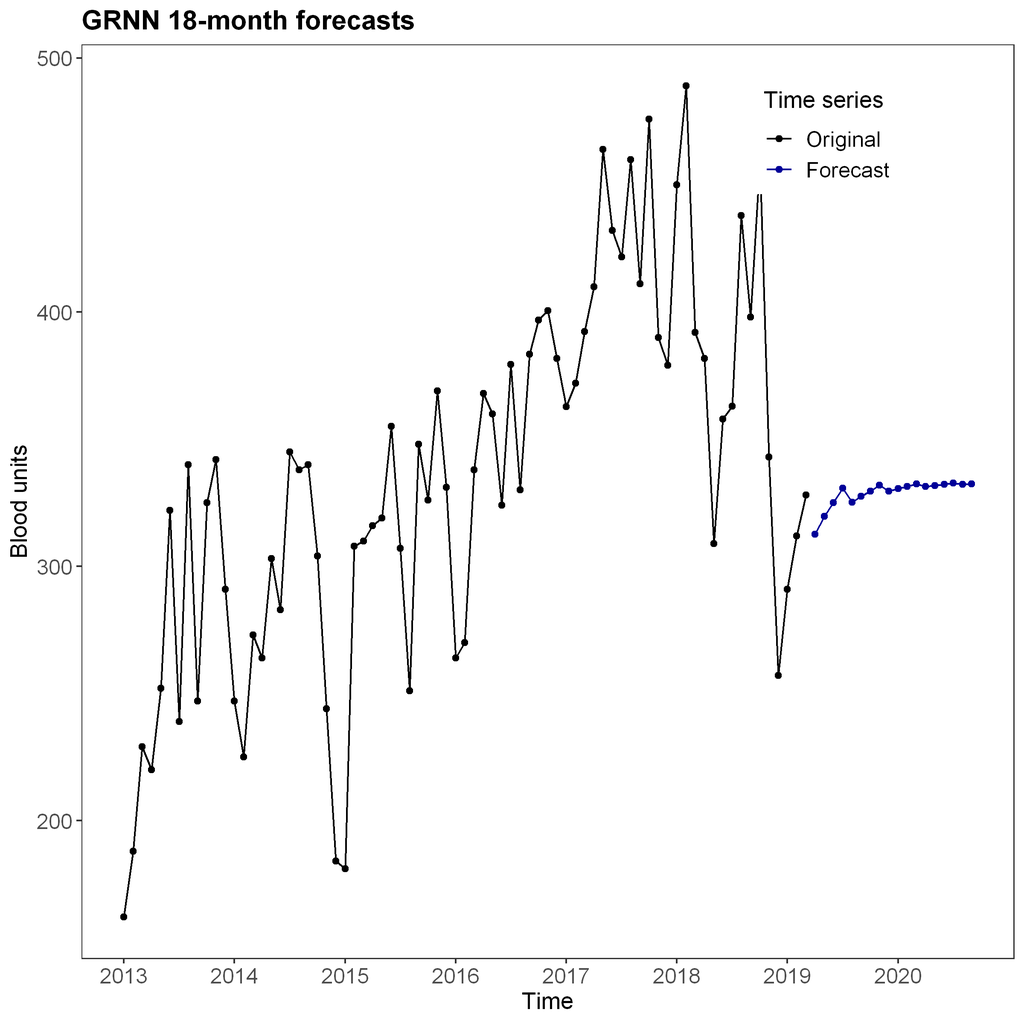

```r
G1<-autoplot.grnnForecast(GRNN_results_forecasts$GRNN_Model[[1]],highlight = c("points"))+
ggtitle("GRNN 18-month forecasts")+ theme_bw()+
theme(panel.grid.major = element_blank(), panel.grid.minor = element_blank(),
panel.background = element_blank())+labs(y="Blood units")+
theme(plot.title = element_text(hjust=0), axis.text.x = element_text(size = 12)
        ,axis.text.y = element_text(size = 12), axis.title.x = element_text(size = 13), axis.title.y = element_text(size = 13))


G1+ scale_x_continuous(breaks=c(2013,2014,2015,2016,2017,2018, 2019,2020),
       labels=c("2013","2014","2015","2016","2017","2018","2019","2020"))+theme(legend.position = c(0.8, 0.9),
                                        legend.title=element_text(size=13),legend.text=element_text(size=12))+
 theme(plot.title = element_text(size=15))+theme(plot.title = element_text(face = "bold"))
```

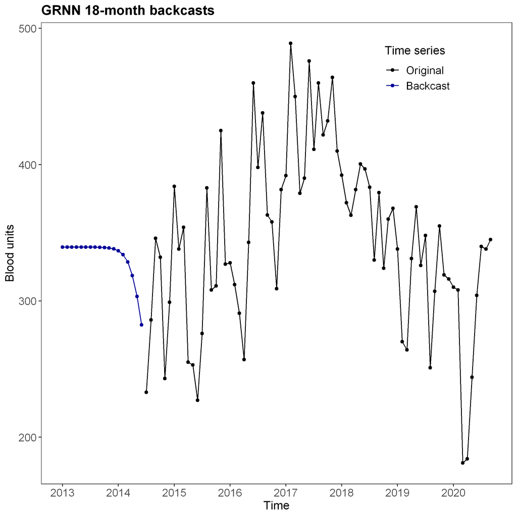

```r
G3<-autoplot.grnnBackcast(GRNN_results_backcasts$GRNN_Model[[1]],highlight = c("points"))+
ggtitle("GRNN 18-month backcasts")+ theme_bw()+
theme(panel.grid.major = element_blank(), panel.grid.minor = element_blank(),
panel.background = element_blank())+labs(y="Blood units")+
theme(plot.title = element_text(hjust=0), axis.text.x = element_text(size = 12)
        ,axis.text.y = element_text(size = 12), axis.title.x = element_text(size = 13), axis.title.y = element_text(size = 13))


G3+ scale_x_continuous(breaks=c(2013,2014,2015,2016,2017,2018, 2019,2020),
       labels=c("2013","2014","2015","2016","2017","2018","2019","2020"))+theme(legend.position = c(0.8, 0.9),
                                        legend.title=element_text(size=13),legend.text=element_text(size=12))+
theme(plot.title = element_text(size=15))+theme(plot.title = element_text(face = "bold"))
```

# MODEL 4 (Machine Learning): Multilayer Perceptron for time series forecasting and backcasting

```r
setwd("C:/Users/user/Desktop/PhD Documents Cardiff_main/PhD Project Chapter 1-6/LATEX PhD Thesis 1/LaTex Files _PhD/Juliet Publication work_Main/Current-Resubmission_IJF_2021/R Scripts")

#Script of function for MLP plots (backcast and forecast)

source("plot-MLP-script.r")

##script of functions for rolling-origin forecast & backcast evaluations for the MLP model
# sel.lag=TRUE automatically select lags
#difforder=NULL automatically determines the differencing order
#hd.auto.type="cv" automatically selects the number of hidden nodes using 5-fold cv (hd) if hd=NULL
source("ro-eval-MLP-script.r")
```

# Rolling-origin forecast evaluation for MLP model

```r
# 18-month forecast
MLP_results_forecasts<- ro_eval_MLP_forecast(series=demand,forecast_length=18,seed.number=NULL)
```

# Forecast: Comparing estimated errors at the different lead times (MLP model)

```r
setwd("C:/Users/user/Desktop/PhD Documents Cardiff_main/PhD Project Chapter 1-6/LATEX PhD Thesis 1/LaTex Files _PhD/Juliet Publication work_Main/Current-Resubmission_IJF_2021")

MLP_results_forecasts$MLP_errors
write.csv(MLP_results_forecasts$MLP_errors,"MLP_results_forecasts_MLP_errors.csv")
```

A data.frame: 17 × 3

|  | RMSE <dbl> | MAE <dbl> | MAPE <dbl> |
| --- | --- | --- | --- |
| Mar 2019 | 90.12537 | 76.83370 | 27.74019 |
| Apr 2019 | 110.63301 | 95.74759 | 34.56608 |
| May 2019 | 75.26951 | 62.74243 | 23.44172 |
| Jun 2019 | 60.92173 | 42.22755 | 15.96515 |
| Jul 2019 | 104.35733 | 90.44112 | 33.79360 |
| Aug 2019 | 124.66498 | 112.85225 | 42.14984 |
| Sep 2019 | 81.31417 | 67.30275 | 25.71272 |
| Oct 2019 | 60.51717 | 51.25713 | 16.33212 |
| Nov 2019 | 52.56634 | 44.62840 | 15.38942 |
| Dec 2019 | 56.65545 | 50.33457 | 16.94821 |
| Jan 2020 | 60.34933 | 49.84518 | 17.81873 |
| Feb 2020 | 71.21637 | 55.51129 | 21.00765 |
| Mar 2020 | 72.81059 | 53.17953 | 21.19648 |
| Apr 2020 | 76.27549 | 57.61910 | 23.16180 |
| May 2020 | 66.23465 | 63.22694 | 22.18393 |
| Jun 2020 | 56.50802 | 51.46964 | 19.54163 |
| Jul 2020 | 90.77436 | 74.80143 | 31.17408 |

# Rolling-origin backcast evaluation for MLP model

```r
# 18-month backcast
MLP_results_backcasts<- ro_eval_MLP_backcast(series=demand,backcast_length=18,seed.number=1)
```

# Backcast: Comparing estimated errors at the different lead times (MLP model)

```r
setwd("C:/Users/user/Desktop/PhD Documents Cardiff_main/PhD Project Chapter 1-6/LATEX PhD Thesis 1/LaTex Files _PhD/Juliet Publication work_Main/Current-Resubmission_IJF_2021")

MLP_results_backcasts$MLP_errors
write.csv(MLP_results_backcasts$MLP_errors,"MLP_results_backcasts_MLP_errors.csv")
```

A data.frame: 17 × 3

|  | RMSE <dbl> | MAE <dbl> | MAPE <dbl> |
| --- | --- | --- | --- |
| Jun 2014 | 78.69573 | 63.20861 | 28.58126 |
| May 2014 | 67.94019 | 57.52954 | 24.30657 |
| Apr 2014 | 66.20379 | 56.62334 | 23.96116 |
| Mar 2014 | 82.30886 | 70.27705 | 31.36948 |
| Feb 2014 | 78.93097 | 63.39764 | 28.82934 |
| Jan 2014 | 74.73781 | 58.88981 | 27.37274 |
| Dec 2013 | 87.70816 | 71.72972 | 33.33048 |
| Nov 2013 | 84.74223 | 75.40960 | 33.47197 |
| Oct 2013 | 75.14589 | 62.17479 | 28.65218 |
| Sep 2013 | 71.30688 | 59.47448 | 28.16303 |
| Aug 2013 | 69.01310 | 55.49059 | 24.97028 |
| Jul 2013 | 78.93511 | 66.56341 | 33.20252 |
| Jun 2013 | 92.12935 | 87.30639 | 40.63425 |
| May 2013 | 90.18415 | 82.25936 | 42.44499 |
| Apr 2013 | 108.10654 | 86.56934 | 48.39674 |
| Mar 2013 | 105.10173 | 87.34602 | 50.37522 |
| Feb 2013 | 56.31227 | 48.96517 | 29.32248 |

# Forecast & Backcast Autoplots (MLP model)

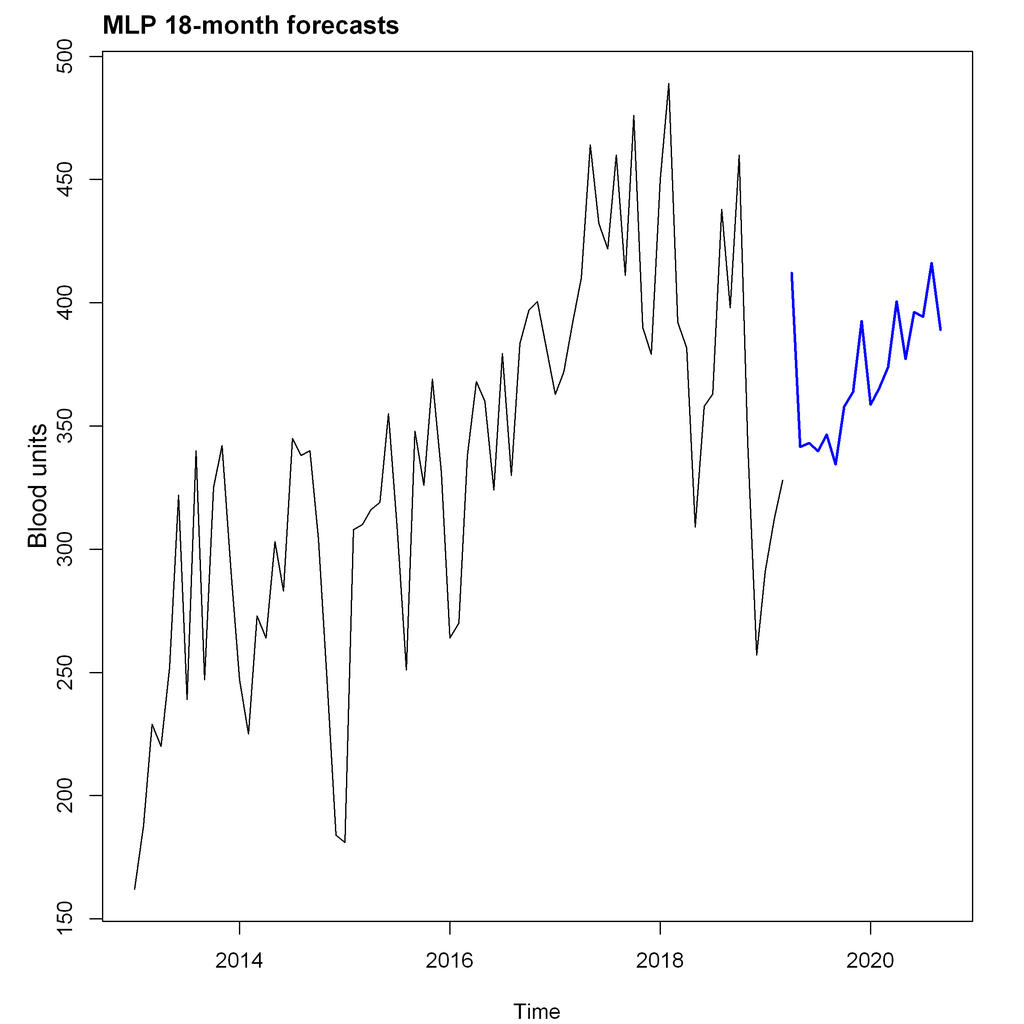

```r
par(mar=c(4,4,2,2))
plot.MLP_forecast(MLP_results_forecasts$MLP_forecasts[[1]],
                  main_title="",
                xaxt = "n",main="",cex=1.2,xlab="")

mtext(text = "Blood units",
      side = 2, #side 2 = left
      line = 2,cex=1.2)


mtext(text = "MLP 18-month forecasts",
      side = 3, #side 2 = left
      line = 0.5,cex=1.2,font=2,adj =0)
```

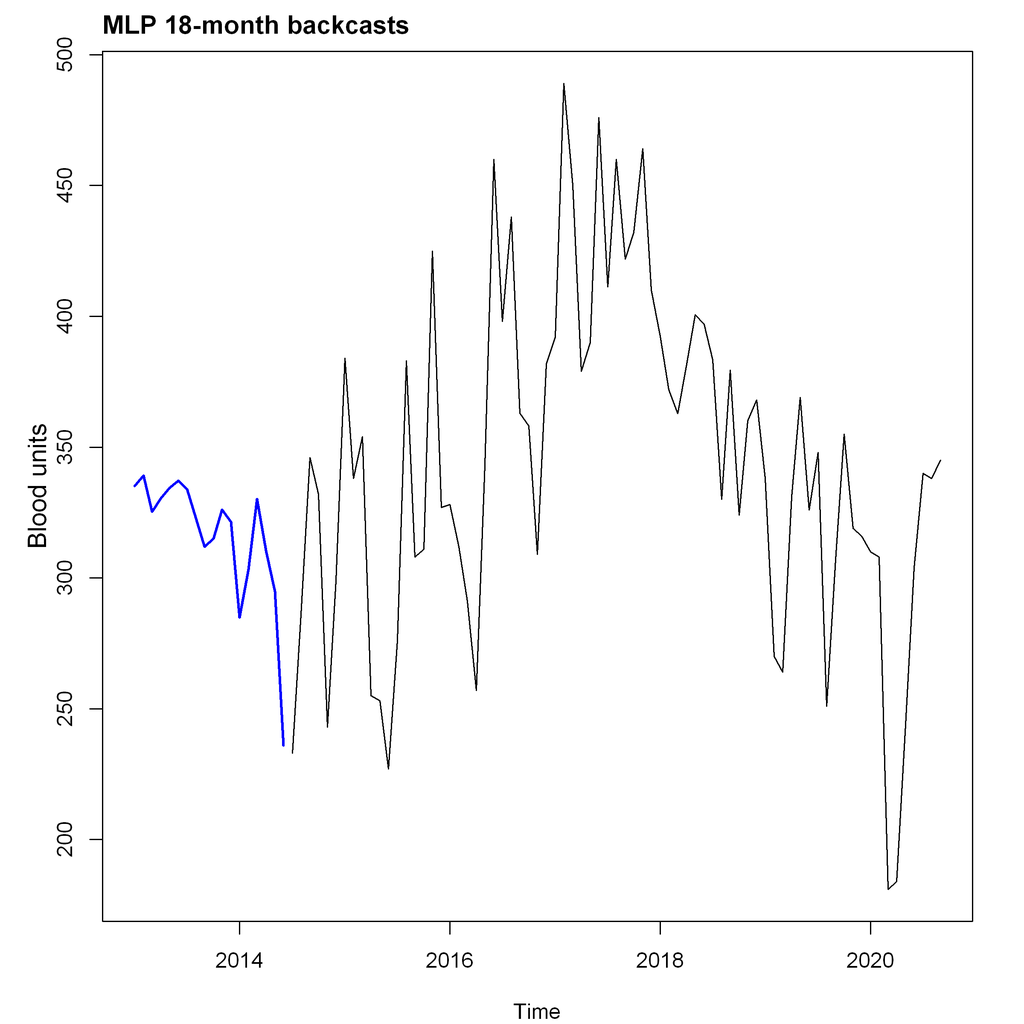

```r
par(mar=c(4,4,2,2))
plot.MLP_reverse(MLP_results_backcasts$MLP_backcasts[[1]],
                 main_title="",
                xaxt = "n",main="",cex=1.2,xlab="")

mtext(text = "Blood units",
      side = 2, #side 2 = left
      line = 2,cex=1.2)


mtext(text = "MLP 18-month backcasts",
      side = 3, #side 2 = left
      line = 0.5,cex=1.2,font=2,adj =0)
```

# Model 5: Extreme learning machines (ELM) neural networks for time series forecasting & backcasting

```r
setwd("C:/Users/user/Desktop/PhD Documents Cardiff_main/PhD Project Chapter 1-6/LATEX PhD Thesis 1/LaTex Files _PhD/Juliet Publication work_Main/Current-Resubmission_IJF_2021/R Scripts")

#Script of function for ELM plots (backcast and forecast)
source("plot-ELM-script.r")

##script of functions for rolling-origin forecast & backcast evaluations for the ELM model
source("ro-eval-ELM-script.r")
```

# Rolling-origin forecast evaluation for ELM model

```r
# 18-month forecast
ELM_results_forecasts<- ro_eval_ELM_forecast(series=demand,forecast_length=18,seed.number=NULL)
```

# Forecast: Comparing estimated errors at the different lead times (ELM model)

```r
setwd("C:/Users/user/Desktop/PhD Documents Cardiff_main/PhD Project Chapter 1-6/LATEX PhD Thesis 1/LaTex Files _PhD/Juliet Publication work_Main/Current-Resubmission_IJF_2021")

ELM_results_forecasts$ELM_errors
write.csv(ELM_results_forecasts$ELM_errors,"ELM_results_forecasts_ELM_errors.csv")
```

A data.frame: 17 × 3

|  | RMSE <dbl> | MAE <dbl> | MAPE <dbl> |
| --- | --- | --- | --- |
| Mar 2019 | 58.16428 | 47.69565 | 16.89252 |
| Apr 2019 | 59.43337 | 50.22269 | 17.73462 |
| May 2019 | 154.93108 | 145.83516 | 52.56393 |
| Jun 2019 | 55.32260 | 47.35543 | 17.20519 |
| Jul 2019 | 58.36064 | 50.37494 | 18.40921 |
| Aug 2019 | 113.68080 | 102.50009 | 38.63216 |
| Sep 2019 | 52.77220 | 46.00351 | 15.28484 |
| Oct 2019 | 91.14013 | 76.73474 | 23.35878 |
| Nov 2019 | 72.64675 | 59.81351 | 17.84387 |
| Dec 2019 | 75.02613 | 65.13185 | 19.46110 |
| Jan 2020 | 62.91887 | 48.39089 | 18.25811 |
| Feb 2020 | 61.14544 | 49.46170 | 18.55775 |
| Mar 2020 | 109.13682 | 100.51022 | 37.63958 |
| Apr 2020 | 49.49784 | 45.35317 | 16.91251 |
| May 2020 | 66.77833 | 59.81294 | 19.15750 |
| Jun 2020 | 62.56746 | 55.71831 | 21.31600 |
| Jul 2020 | 94.27434 | 89.98182 | 36.15887 |

# Rolling-origin backcast evaluation for ELM model

```r
# 18-month backcast
ELM_results_backcasts<- ro_eval_ELM_backcast(series=demand,backcast_length=18,seed.number=1)
```

# Backcast: Comparing estimated errors at the different lead times (ELM model)

```r
setwd("C:/Users/user/Desktop/PhD Documents Cardiff_main/PhD Project Chapter 1-6/LATEX PhD Thesis 1/LaTex Files _PhD/Juliet Publication work_Main/Current-Resubmission_IJF_2021")

ELM_results_backcasts$ELM_errors
write.csv(ELM_results_backcasts$ELM_errors,"ELM_results_backcasts_ELM_errors.csv")
```

A data.frame: 17 × 3

|  | RMSE <dbl> | MAE <dbl> | MAPE <dbl> |
| --- | --- | --- | --- |
| Jun 2014 | 51.20709 | 40.98693 | 15.91228 |
| May 2014 | 52.80499 | 43.00635 | 16.72012 |
| Apr 2014 | 54.66795 | 41.97716 | 15.76320 |
| Mar 2014 | 54.29091 | 42.22260 | 16.18743 |
| Feb 2014 | 54.18277 | 45.75853 | 19.31826 |
| Jan 2014 | 57.59050 | 49.49589 | 20.78252 |
| Dec 2013 | 59.71972 | 49.87676 | 19.36575 |
| Nov 2013 | 61.78088 | 48.72023 | 18.40884 |
| Oct 2013 | 58.71293 | 51.48902 | 21.97872 |
| Sep 2013 | 53.07558 | 41.28443 | 17.81743 |
| Aug 2013 | 59.68747 | 46.21373 | 19.68319 |
| Jul 2013 | 50.26813 | 39.42550 | 18.64263 |
| Jun 2013 | 55.32995 | 46.51794 | 21.84001 |
| May 2013 | 48.85970 | 39.70412 | 21.52084 |
| Apr 2013 | 47.13764 | 36.72051 | 20.83811 |
| Mar 2013 | 63.97238 | 54.10689 | 31.10819 |
| Feb 2013 | 76.51562 | 74.98446 | 43.73614 |